# Grass/PDO model selection

Erica Christensen

5/12/2022

What components of climate are best correlated to perennial grass cover 1916-1979? We start with a list of climate variables that vary at different time scales: short-term variables that vary year to year, El Nino Southern Oscillation (ENSO)-related variables that vary on a 5-7 year time scale, and Pacific Decadal Oscillation (PDO)-related variables that vary on a 30-40 year time scale. First we select variables that are independent from each other and have the best correlative values with grass cover, then test variables in linear models.

## Select short-term variables

Short-term climate variables that are expected to affect perennial grasses: total yearly precipitation, total summer (growing season) precipitation, total winter (non-growing season) precipitation, yearly average Palmer Drought Severity Index (PDSI), summer average PDSI, yearly average Standardized Precipitation-Evapotranspiration Index (SPEI), summer average SPEI, summer De Martonne index, and mean annual temperature.

We looked at cross-correlation plots to determine if lags should be considered.

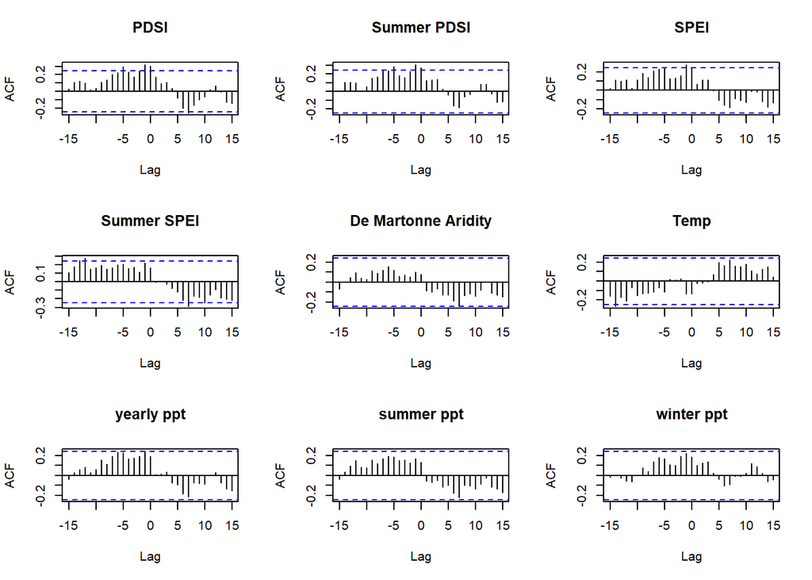

A lag of 1 may be important for yearly precip, PDSI, SPEI, and summer PDSI. We then looked at Pearson’s correlation between each variable and grass to determine if a relationship likely exists. We also looked at scatterplots to determine if a non-linear relationship was needed.

```
##                        variable pearsons pvalue
## grass                     grass    1.000     NA
## pdsi                       pdsi    0.302  0.015
## spei                       spei    0.236  0.061
## mean_temp             mean_temp   -0.134  0.292
## summer_pdsi         summer_pdsi    0.268  0.032
## summer_spei         summer_spei    0.166  0.189
## yearly_ppt_mm     yearly_ppt_mm    0.193  0.126
## summer_ppt_mm     summer_ppt_mm    0.131  0.303
## winter_ppt_mm     winter_ppt_mm    0.186  0.142
## demartonne           demartonne    0.078  0.541
## summerpdsi_lag1 summerpdsi_lag1    0.316  0.011
## spei_lag1             spei_lag1    0.293  0.019
## pdsi_lag1             pdsi_lag1    0.333  0.007
## yearlyppt_lag1   yearlyppt_lag1    0.252  0.045
```

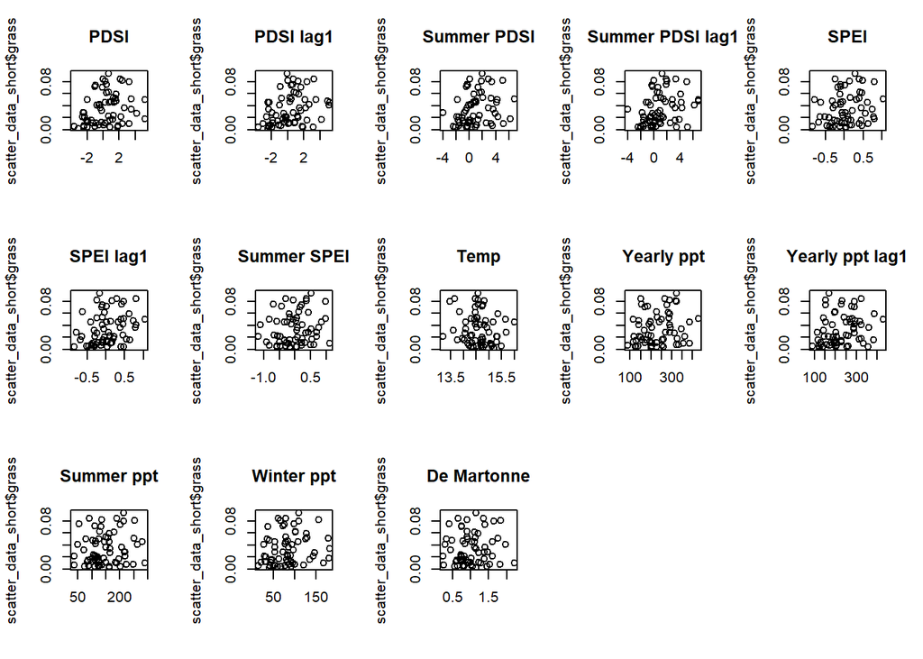

There is no evidence that non-linear relationships need to be included. There is poor correlation between grass and De Martonne, temperature, summer ppt, summer spei, winter ppt, and yearly ppt so these were removed from consideration. Finally, we looked for correlations among remaining variables.

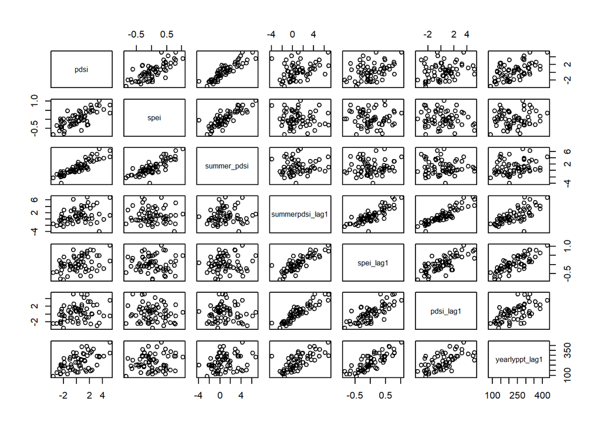

PDSI and SPEI are highly correlated. We chose to proceed with variables PDSI and PDSI lag1, as these variables had the highest correlation with grass and are not correlated with each other.

## Select ENSO variables

We repeated the above process with several ENSO-related variables: Nino 3.4 index, Oceanic Nino Index (ONI), and the categorical variable of ENSO phase (each year is categorized as El Nino, La Nina, or Neutral).

We looked at cross-correlation plots to determine if lags should be considered.

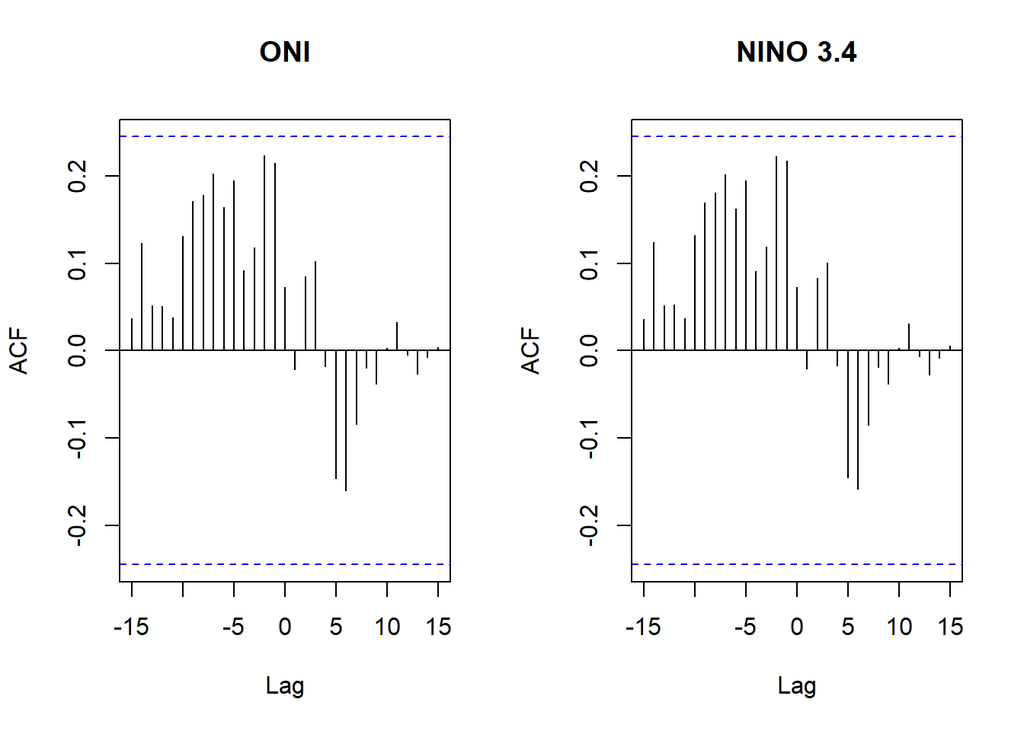

No lags need be considered for these variables. Next we looked at Pearson’s correlation and scatterplots

```
##        variable pearsons pvalue
## grass     grass    1.000     NA
## oni         oni    0.073  0.567
## nino34   nino34    0.072  0.571
```

```
##             Df  Sum Sq   Mean Sq F value Pr(>F)
## enso_phase   2 0.00301 0.0015063    2.34  0.105
## Residuals   61 0.03926 0.0006436
```

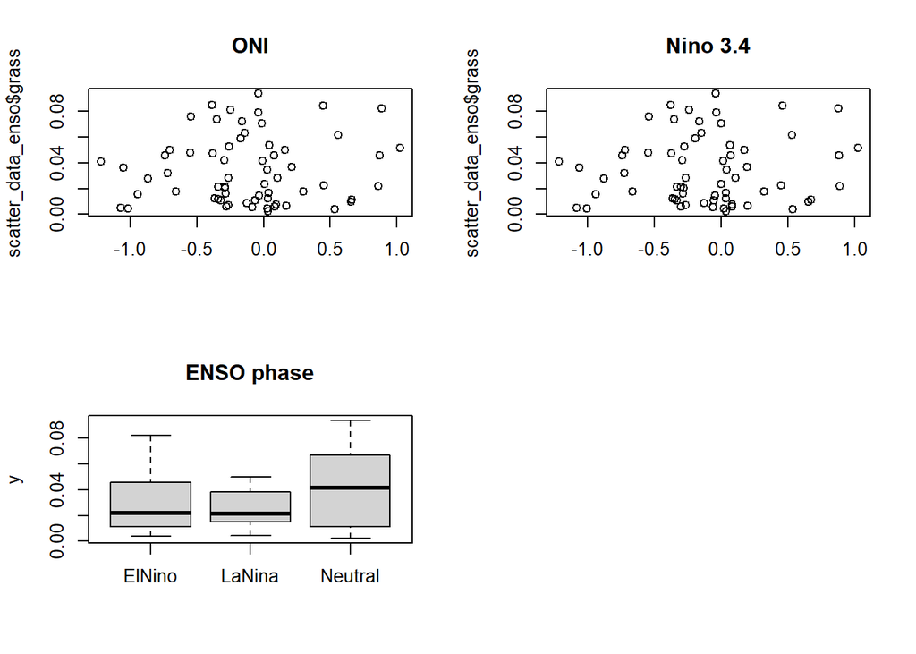

There is no significant correlation between grass and any of the ENSO variables.

## Select PDO variables

We repeated the above process to determine the significance of the PDO index and PDO phase (categorical).

We first looked at cross-correlation plots to determine if lags should be considered.

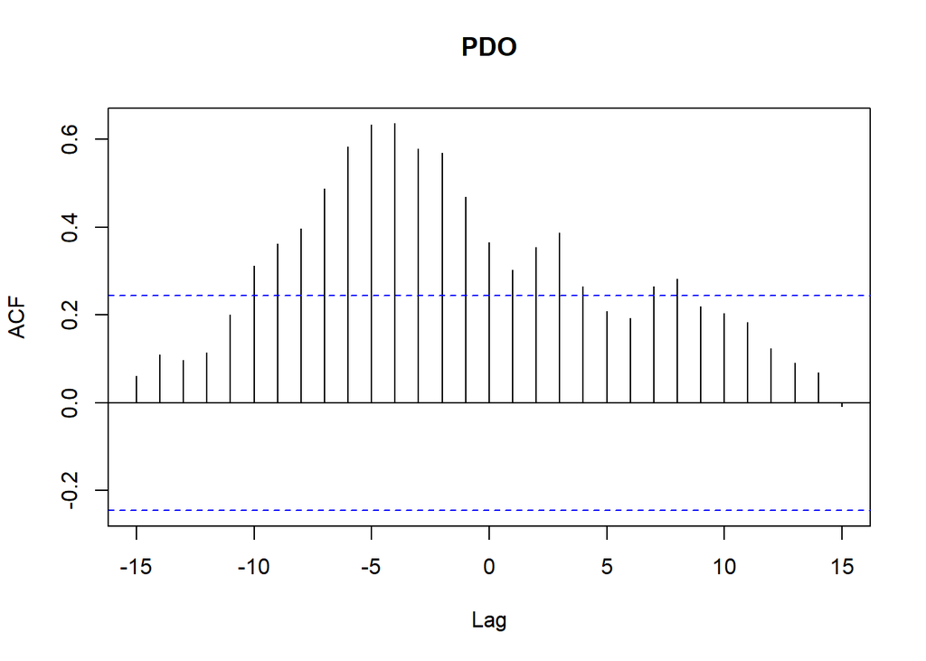

Lag of 0-10 appear to be significant for PDO index. Rather than creating a new variable for each lag, we created a 10-year moving average smooth of the PDO index.

We next looked at Pearson’s correlation and scatterplots.

```
##                  variable pearsons pvalue
## grass               grass    1.000     NA
## pdo                   pdo    0.365  0.003
## pdo_mean_10y pdo_mean_10y    0.795  0.000
```

```
##             Df  Sum Sq  Mean Sq F value   Pr(>F)
## pdo_phase    1 0.02168 0.021684    65.3 2.87e-11 ***
## Residuals   62 0.02059 0.000332
## ---
## Signif. codes:  0 '***' 0.001 '**' 0.01 '*' 0.05 '.' 0.1 ' ' 1
```

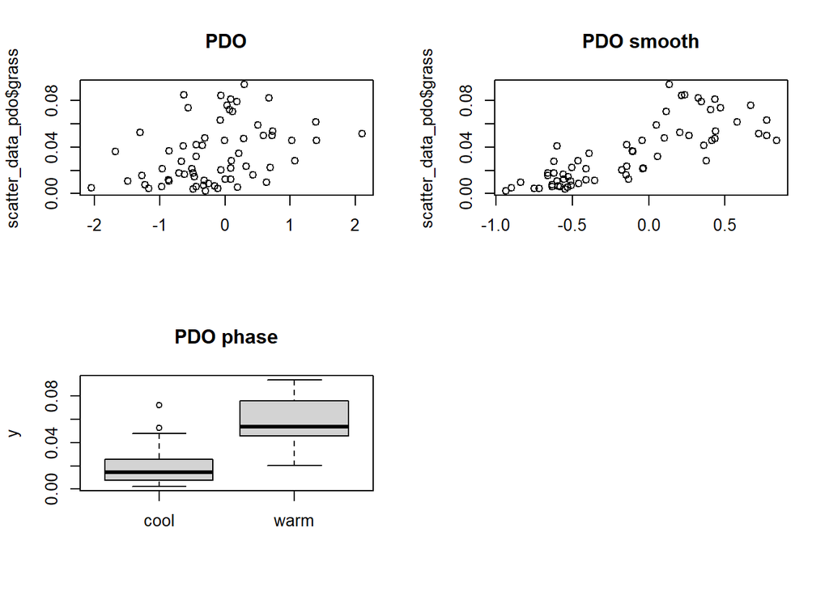

There is no evidence that nonlinear relationships should be considered. PDO, PDO phase, and the PDO smooth are all significantly correlated with grass. We looked for dependence among the variables.

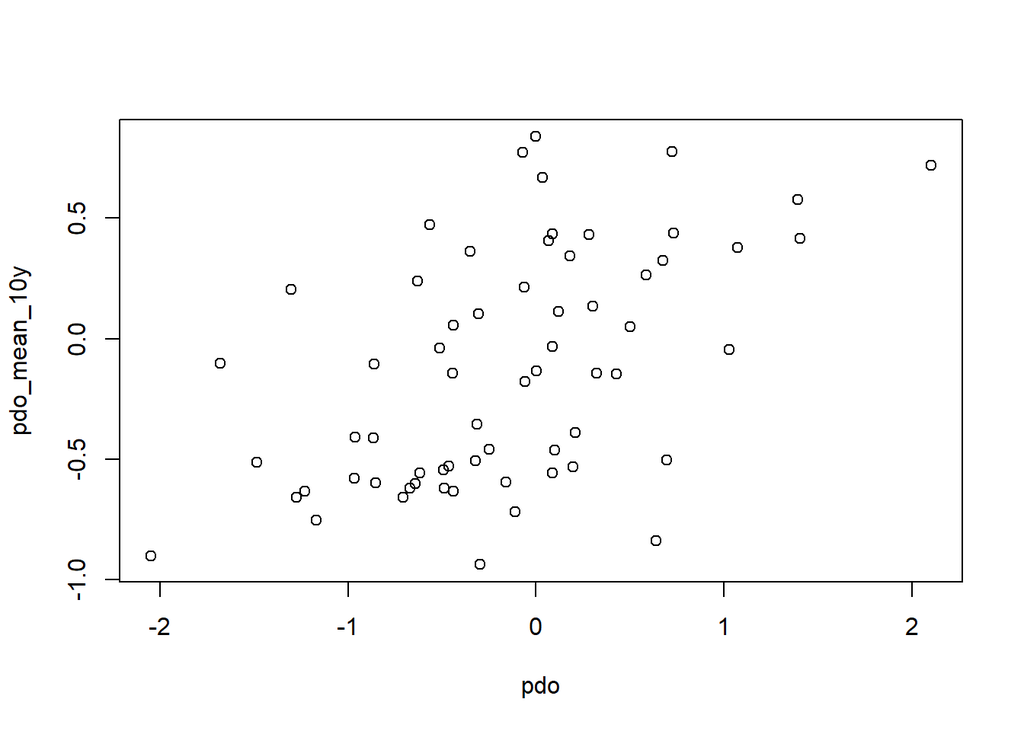

```
##
## Call:
## lm(formula = pdo ~ pdo_mean_10y, data = scatter_data_pdo)
##
## Residuals:
##      Min       1Q   Median       3Q      Max
## -1.54796 -0.44757  0.01501  0.46393  1.55508
##
## Coefficients:
##              Estimate Std. Error t value Pr(>|t|)
## (Intercept)  -0.04805    0.08498  -0.565    0.574
## pdo_mean_10y  0.82562    0.17071   4.837  9.1e-06 ***
## ---
## Signif. codes:  0 '***' 0.001 '**' 0.01 '*' 0.05 '.' 0.1 ' ' 1
##
## Residual standard error: 0.6557 on 62 degrees of freedom
## Multiple R-squared:  0.2739, Adjusted R-squared:  0.2622
## F-statistic: 23.39 on 1 and 62 DF,  p-value: 9.098e-06
```

```
##             Df Sum Sq Mean Sq F value   Pr(>F)
## pdo_phase    1  6.991   6.991   55.84 3.26e-10 ***
## Residuals   62  7.763   0.125
## ---
## Signif. codes:  0 '***' 0.001 '**' 0.01 '*' 0.05 '.' 0.1 ' ' 1
```

Not surprisingly there is significant correlation between PDO and PDO smooth, and between PDO phase and PDO smooth. We chose to proceed with PDO smooth as this variable had the highest Pearson’s correlation with grass.